# Notebook

**Das Skalarprodukt - Herz der Linearen Regression**

Dr. Matthias Hölzl

## Unser Muster wiederholen

Erinnern Sie sich an unsere Vorhersageberechnung:

1. Feature × Koeffizient für jedes Feature
2. Alle Produkte addieren
3. Intercept addieren

```python
import numpy as np
```

Unser vertrautes Beispiel

```python
features = [5.0, 7.0, 3.0]  # distance, traffic, pizzas
coefficients = [2.0, 1.5, 0.5]
```

Manuelle Berechnung

```python
result = 0
for f, c in zip(features, coefficients):
    result += f * c
    print(f"{f} × {c} = {f * c}")
```

```
5.0 × 2.0 = 10.0
7.0 × 1.5 = 10.5
3.0 × 0.5 = 1.5
```

Summe:

```python
result
```

```
22.0
```

## Dieses Muster hat einen Namen!

**Skalarprodukt** (Dot Product):

- Multipliziere entsprechende Elemente
- Addiere alle Produkte
- Ergebnis ist eine einzelne Zahl (Skalar)

## Das Skalarprodukt verstehen

Für zwei Vektoren a und b:

- a = [a₁, a₂, a₃]
- b = [b₁, b₂, b₃]
- a · b = a₁×b₁ + a₂×b₂ + a₃×b₃

## Beispiel: Schritt für Schritt

Zwei Vektoren

```python
a = [2, 3, 4]
b = [5, 1, 2]
```

Berechne Skalarprodukt manuell

```python
dot_product = 0
print("Calculating dot product:")
for i in range(len(a)):
    product = a[i] * b[i]
    dot_product += product
    print(f"Position {i}: {a[i]} × {b[i]} = {product}")
```

```
Calculating dot product:
Position 0: 2 × 5 = 10
Position 1: 3 × 1 = 3
Position 2: 4 × 2 = 8
```

```python
dot_product
```

```
21
```

## Geometrische Bedeutung

Das Skalarprodukt misst gleichzeitig:

- Ob zwei Vektoren in ähnliche Richtung zeigen
  - Größer wenn Vektoren in ähnliche Richtung zeigen
  - Null wenn Vektoren senkrecht stehen
  - Negativ wenn Vektoren entgegengesetzt zeigen
- Wie lang die Vektoren sind
  - Bei Vektoren in gleicher Richtung: je länger, desto größer das Skalarprodukt

```python
import matplotlib.pyplot as plt
from plot_utils import plot_dot_product_relationship
```

Visualisiere Skalarprodukt-Beziehung

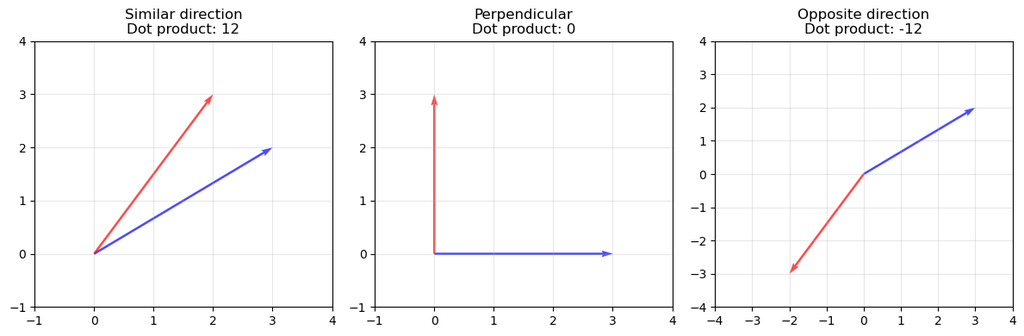

```python
plot_dot_product_relationship()
```

## Skalarprodukt in NumPy

NumPy macht das Skalarprodukt einfach:

```python
a = np.array([2, 3, 4])
b = np.array([5, 1, 2])
```

Methode 1: np.dot()

```python
dot_result = np.dot(a, b)
```

```python
dot_result
```

```
np.int64(21)
```

Methode 2: @ Operator (Python 3.5+)

```python
dot_result2 = a @ b
```

```python
dot_result2
```

```
np.int64(21)
```

Vergleiche mit manueller Berechnung

```python
a
```

```
array([2, 3, 4])
```

```python
b
```

```
array([5, 1, 2])
```

```python
2*5 + 3*1 + 4*2
```

```
21
```

```python
int(a @ b)
```

```
21
```

## Warum ist das wichtig für ML?

Lineare Regression ist ein riesiges Skalarprodukt!

- Features = ein Vektor
- Koeffizienten = ein anderer Vektor
- Vorhersage = Skalarprodukt + Intercept

## Vorhersagen mit dem Skalarprodukt

Erinnern Sie sich an unser Pizza-Lieferbeispiel:

- Features: [Entfernung, Verkehr, Anzahl Pizzen]
- Koeffizienten: [2.0, 1.5, 0.5]
- Intercept: 8.0

```python
features = np.array([5.0, 7.0, 3.0])  # distance, traffic, pizzas
coefficients = np.array([2.0, 1.5, 0.5])
intercept = 8.0
```

Alte Methode mit Schleife

```python
prediction_loop = 0
for f, c in zip(features, coefficients):
    prediction_loop += f * c
prediction_loop += intercept
print(f"Prediction (loop): {prediction_loop}")
```

```
Prediction (loop): 30.0
```

Neue Methode mit Skalarprodukt

```python
prediction_dot = np.dot(features, coefficients) + intercept
print(f"Prediction (dot product): {prediction_dot}")
```

```
Prediction (dot product): 30.0
```

Noch kürzer mit @

```python
prediction_at = features @ coefficients + intercept
print(f"Prediction (@ operator): {prediction_at}")
```

```
Prediction (@ operator): 30.0
```

## Eine Vorhersagefunktion bauen

```python
def predict_single(features, coefficients, intercept):
    """
    Make a prediction using linear regression.

    Parameters:
    - features: array of feature values
    - coefficients: array of model coefficients
    - intercept: model intercept

    Returns:
    - prediction: single predicted value
    """
    features = np.array(features)
    coefficients = np.array(coefficients)
    return features @ coefficients + intercept
```

### Testen der Funktion

```python
test_features = [5.0, 7.0, 3.0]
test_coef = [2.0, 1.5, 0.5]
test_intercept = 8.0
```

```python
predict_single(test_features, test_coef, test_intercept)
```

```
np.float64(30.0)
```

## Das Skalarprodukt in der Praxis

Warum ist das Skalarprodukt so wichtig?

- **Effizienz**: Eine Operation statt einer Schleife
- **Klarheit**: Mathematisch präzise
- **Universell**: Funktioniert für beliebig viele Features
- **Optimiert**: NumPy nutzt optimierte C-Bibliotheken

## Geschwindigkeitsvergleich

```python
import time
```

Erstelle große Vektoren

```python
n = 1_000_000
large_features = np.random.randn(n)
large_coefficients = np.random.randn(n)
```

Zeitmessung für Schleifenversion

```python
start = time.time()
result_loop = 0
for f, c in zip(large_features, large_coefficients):
    result_loop += f * c
time_loop = time.time() - start
```

Zeitmessung für NumPy-Version

```python
start = time.time()
result_numpy = np.dot(large_features, large_coefficients)
time_numpy = time.time() - start
```

```python
print(f"Loop version: {time_loop:.4f} seconds")
print(f"NumPy version: {time_numpy:.4f} seconds")
print(f"NumPy is {time_loop/time_numpy:.1f}x faster!")
print(f"Results match: {np.allclose(result_loop, result_numpy)}")
```

```
Loop version: 0.2364 seconds
NumPy version: 0.0061 seconds
NumPy is 38.5x faster!
Results match: True
```

## Zusammenfassung

- Das Skalarprodukt ist die Kernoperation der linearen Regression
- Multipliziere entsprechende Elemente, dann summiere
- NumPy: `np.dot(a, b)` oder `a @ b`
- Vorhersage = features @ coefficients + intercept
- Viel schneller und klarer als Schleifen!

## Nächste Schritte

- Wir können jetzt einzelne Vorhersagen effizient berechnen
- Was ist mit vielen Vorhersagen gleichzeitig?
- Nächstes Thema: Matrizen und Batch-Vorhersagen
- Von Vektoren zu 2D-Arrays!

## Workshop: Hauspreisvorhersage mit Skalarprodukt

### Modell für Hauspreise

```python
feature_names = ["size_sqm", "bedrooms", "bathrooms", "age_years", "has_garage"]
model_coefficients = np.array([0.5, 25.0, 20.0, -1.5, 30.0])  # in thousands
model_intercept = 100.0  # base price in thousands
```

```python
print("House Price Model (in thousands €):")
for name, coef in zip(feature_names, model_coefficients):
    print(f"{name:15}: {coef:+8.1f}k€")
print(f"{'Base price':15}: {model_intercept:8.1f}k€")
```

```
House Price Model (in thousands €):
size_sqm       :     +0.5k€
bedrooms       :    +25.0k€
bathrooms      :    +20.0k€
age_years      :     -1.5k€
has_garage     :    +30.0k€
Base price     :    100.0k€
```

### Aufgabe 1: Einzelne Vorhersage

Berechnen Sie den Preis für dieses Haus mit dem Skalarprodukt:

- 150 m²
- 4 Schlafzimmer
- 2 Badezimmer
- 5 Jahre alt
- Hat Garage (1 = ja)

```python
house1 = np.array([150, 4, 2, 5, 1])
```

Verwende Skalarprodukt

```python
price1 = np.dot(house1, model_coefficients) + model_intercept
print(f"House features: {house1}")
print(f"Predicted price: {price1:.1f}k€")
```

```
House features: [150   4   2   5   1]
Predicted price: 337.5k€
```

Zeige Berechnungsdetails

```python
contributions = house1 * model_coefficients
print("\nDetailed calculation:")
for name, feature, coef, contrib in zip(feature_names, house1, model_coefficients, contributions):
    print(f"{name:15}: {feature:3} × {coef:+6.1f} = {contrib:+7.1f}k€")
print(f"{'Base price':15}:              = {model_intercept:+7.1f}k€")
print(f"{'Total':15}:              = {price1:7.1f}k€")
```

```
Detailed calculation:
size_sqm       : 150 ×   +0.5 =   +75.0k€
bedrooms       :   4 ×  +25.0 =  +100.0k€
bathrooms      :   2 ×  +20.0 =   +40.0k€
age_years      :   5 ×   -1.5 =    -7.5k€
has_garage     :   1 ×  +30.0 =   +30.0k€
Base price     :              =  +100.0k€
Total          :              =   337.5k€
```

### Aufgabe 2: Mehrere Häuser vergleichen

Vergleichen Sie drei verschiedene Häuser und finden Sie das beste Preis-Leistungs-Verhältnis (Vorhergesagter Preis pro m²).

```python
houses = {
    "House A": np.array([100, 3, 1, 10, 0]),  # 100m², 3 bed, 1 bath, 10 years, no garage
    "House B": np.array([180, 4, 3, 2, 1]),   # 180m², 4 bed, 3 bath, 2 years, garage
    "House C": np.array([120, 2, 2, 20, 1]),  # 120m², 2 bed, 2 bath, 20 years, garage
}
```

```python
print("House Price Comparison:")
print("-" * 50)
```

```
House Price Comparison:
--------------------------------------------------
```

```python
best_value = float('inf')
best_house = None
```

```python
for name, features in houses.items():
    price = features @ model_coefficients + model_intercept
    price_per_sqm = price / features[0]  # features[0] is size_sqm

    print(f"{name}:")
    print(f"  Features: {features}")
    print(f"  Price: {price:.1f}k€")
    print(f"  Price per m²: {price_per_sqm:.3f}k€")

    if price_per_sqm < best_value:
        best_value = price_per_sqm
        best_house = name
```

```
House A:
  Features: [100   3   1  10   0]
  Price: 230.0k€
  Price per m²: 2.300k€
House B:
  Features: [180   4   3   2   1]
  Price: 377.0k€
  Price per m²: 2.094k€
House C:
  Features: [120   2   2  20   1]
  Price: 250.0k€
  Price per m²: 2.083k€
```

```python
print(f"\nBest value: {best_house} at {best_value:.3f}k€ per m²")
```

```
Best value: House C at 2.083k€ per m²
```

### Aufgabe 3: Feature-Wichtigkeit analysieren

Welches Feature hat den größten Einfluss auf den Preis?

**Tipp:** Schauen Sie sich die Koeffizienten an, aber bedenken Sie auch die Wertebereiche der Features!

Bereiche für Features

```python
typical_ranges = {
    "size_sqm": (100, 180),
    "bedrooms": (2, 4),
    "bathrooms": (1, 3),
    "age_years": (2, 20),
    "has_garage": (0, 1)
}
```

```python
print("Feature Impact Analysis:")
print("-" * 60)
```

```
Feature Impact Analysis:
------------------------------------------------------------
```

```python
for i, (name, (min_val, max_val)) in enumerate(typical_ranges.items()):
    coef = model_coefficients[i]
    max_impact = coef * (max_val - min_val)
    print(f"{name:15}: Coefficient = {coef:+4.1f}k€")
    print(f"{'':15}  Range: {min_val} to {max_val}")
    print(f"{'':15}  Max impact: {abs(max_impact):.1f}k€")
    print()
```

```
size_sqm       : Coefficient = +0.5k€
                 Range: 100 to 180
                 Max impact: 40.0k€

bedrooms       : Coefficient = +25.0k€
                 Range: 2 to 4
                 Max impact: 50.0k€

bathrooms      : Coefficient = +20.0k€
                 Range: 1 to 3
                 Max impact: 40.0k€

age_years      : Coefficient = -1.5k€
                 Range: 2 to 20
                 Max impact: 27.0k€

has_garage     : Coefficient = +30.0k€
                 Range: 0 to 1
                 Max impact: 30.0k€
```

- Das Feature mit dem größten absoluten Koeffizienten ist nicht immer am wichtigsten!
- Man muss den Wertebereich berücksichtigen, den es annehmen kann.

Plot der Einflüsse

```python
import matplotlib.pyplot as plt
```

```python
feature_impacts = []
feature_labels = []
for i, (name, (min_val, max_val)) in enumerate(typical_ranges.items()):
    coef = model_coefficients[i]
    max_impact = coef * (max_val - min_val)
    feature_impacts.append(abs(max_impact))
    feature_labels.append(name)
```

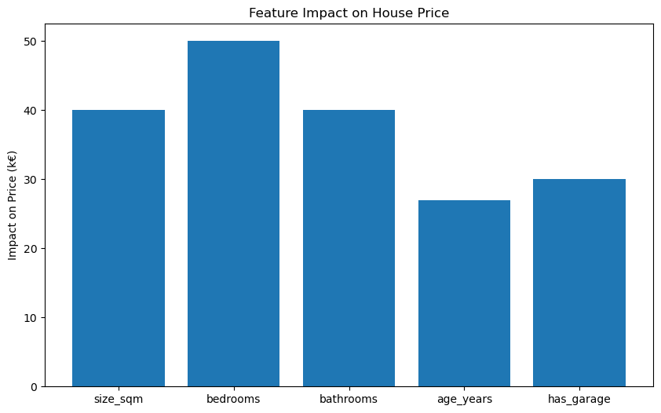

```python
plt.figure(figsize=(10, 6))
plt.bar(feature_labels, feature_impacts)
plt.ylabel('Impact on Price (k€)')
plt.title('Feature Impact on House Price')
plt.show()
```

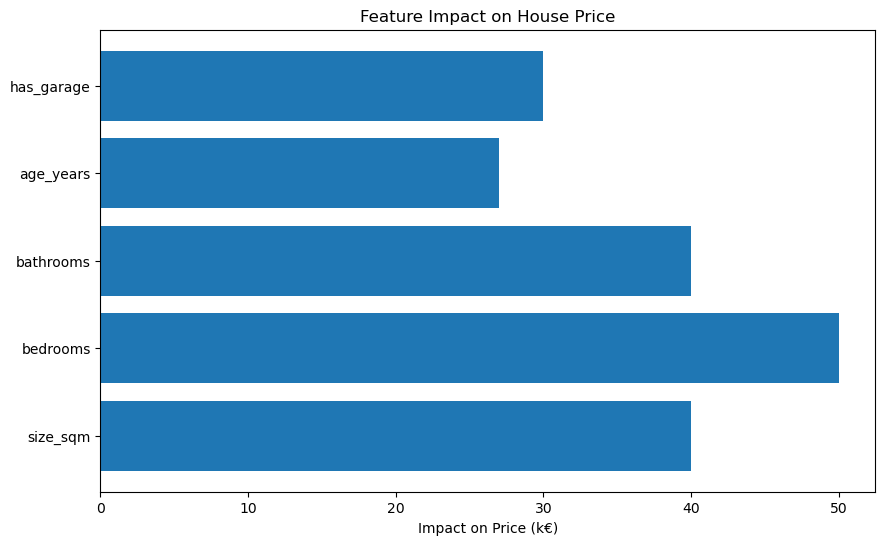

```python
plt.figure(figsize=(10, 6))
plt.barh(feature_labels, feature_impacts)
plt.xlabel('Impact on Price (k€)')
plt.title('Feature Impact on House Price')
plt.show()
```